# AIMD Hospital Liver Disease Prediction

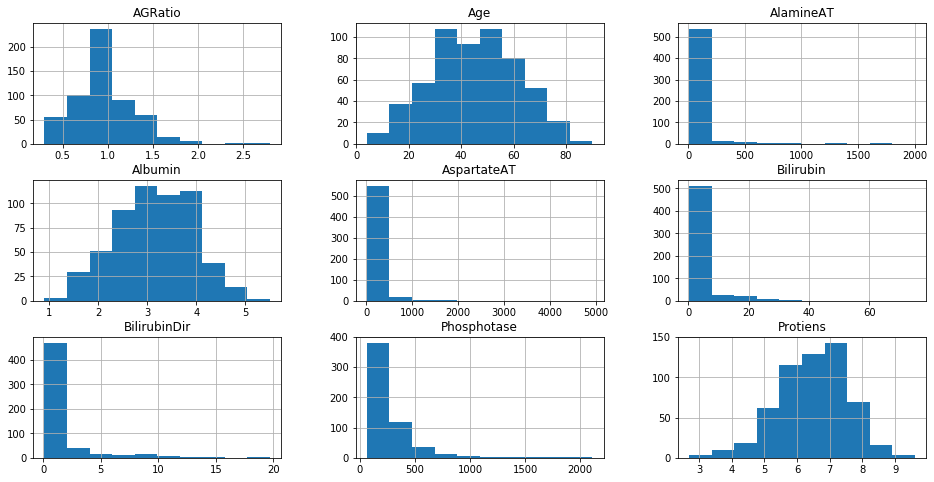

```python
# Plot the distributions
aimd.drop(['Disease'], axis=1).hist(figsize=[16,8], bins=10, layout=(3,3))
plt.show()
```

```python
# Check null values
aimd.isnull().sum()
```

```
Age             0
Bilirubin       0
BilirubinDir    0
Phosphotase     0
AlamineAT       0
AspartateAT     0
Protiens        0
Albumin         0
AGRatio         4
Disease         0
dtype: int64
```

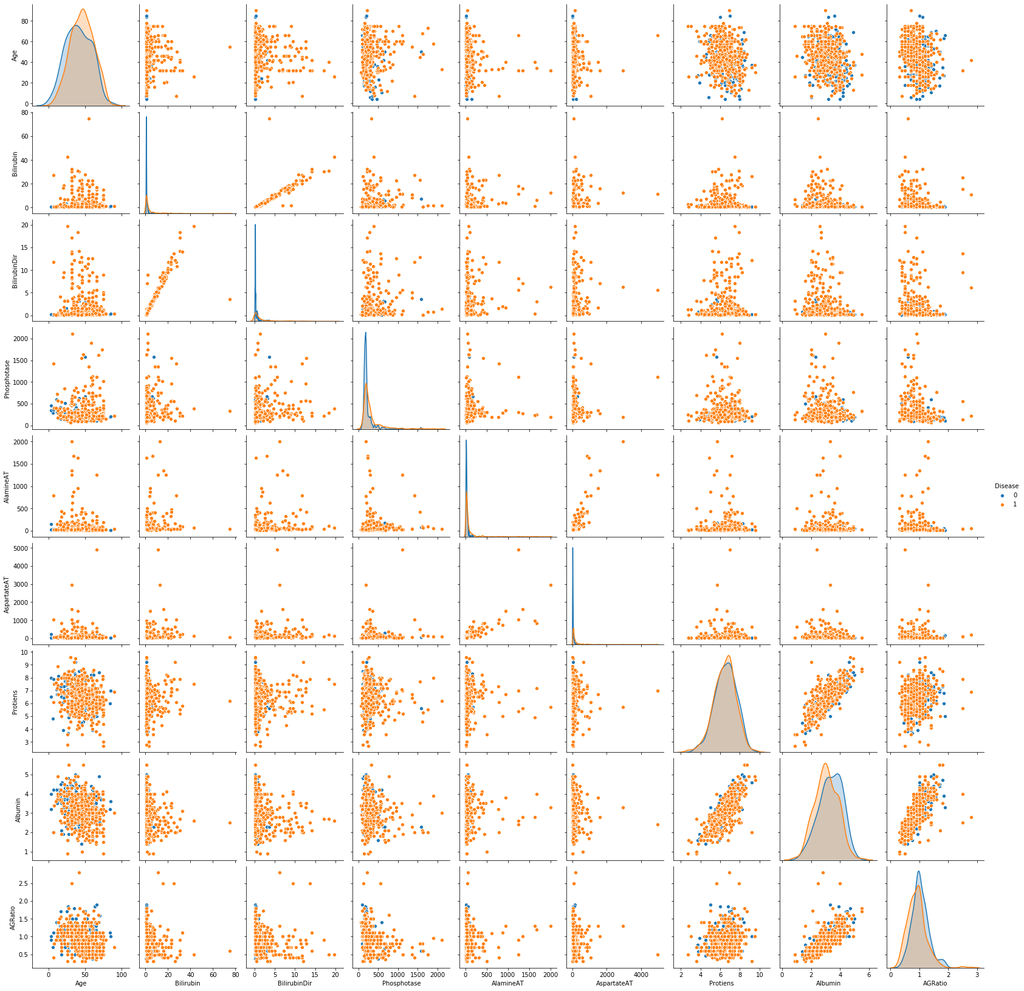

```python
# Scatter and pair plots of data
sb.pairplot(aimd, diag_kind='kde', hue='Disease')
plt.show()
```

```python
# AGRatio is right-skewed, impute using median
from sklearn.impute import SimpleImputer
aimd['AGRatio'] = SimpleImputer(strategy='median', copy=False).fit(aimd[['AGRatio']]).transform(aimd[['AGRatio']])
aimd.isna().sum()
# OR
#aimd.loc[aimd[aimd['AGRatio'].isnull()].index, 'AGRatio'] = aimd['AGRatio'].median()
```

```
Age             0
Bilirubin       0
BilirubinDir    0
Phosphotase     0
AlamineAT       0
AspartateAT     0
Protiens        0
Albumin         0
AGRatio         0
Disease         0
dtype: int64
```

```python
# Check the correlation matrix (exclude Disease)
corr = aimd.iloc[:,:-1].corr()
corr
```

|  | Age | Bilirubin | BilirubinDir | Phosphotase | AlamineAT | AspartateAT | Protiens | Albumin | AGRatio |
| --- | --- | --- | --- | --- | --- | --- | --- | --- | --- |
| Age | 1.000000 | 0.011500 | 0.007050 | 0.081673 | -0.083383 | -0.016753 | -0.197052 | -0.271170 | -0.215654 |
| Bilirubin | 0.011500 | 1.000000 | 0.874116 | 0.206239 | 0.217471 | 0.238678 | -0.008588 | -0.224124 | -0.207646 |
| BilirubinDir | 0.007050 | 0.874116 | 1.000000 | 0.234609 | 0.237450 | 0.258489 | -0.000875 | -0.230751 | -0.201412 |
| Phosphotase | 0.081673 | 0.206239 | 0.234609 | 1.000000 | 0.126830 | 0.167230 | -0.030048 | -0.168318 | -0.236058 |
| AlamineAT | -0.083383 | 0.217471 | 0.237450 | 0.126830 | 1.000000 | 0.791857 | -0.035193 | -0.027973 | -0.006537 |
| AspartateAT | -0.016753 | 0.238678 | 0.258489 | 0.167230 | 0.791857 | 1.000000 | -0.022000 | -0.085180 | -0.072893 |
| Protiens | -0.197052 | -0.008588 | -0.000875 | -0.030048 | -0.035193 | -0.022000 | 1.000000 | 0.784731 | 0.233588 |
| Albumin | -0.271170 | -0.224124 | -0.230751 | -0.168318 | -0.027973 | -0.085180 | 0.784731 | 1.000000 | 0.684126 |
| AGRatio | -0.215654 | -0.207646 | -0.201412 | -0.236058 | -0.006537 | -0.072893 | 0.233588 | 0.684126 | 1.000000 |

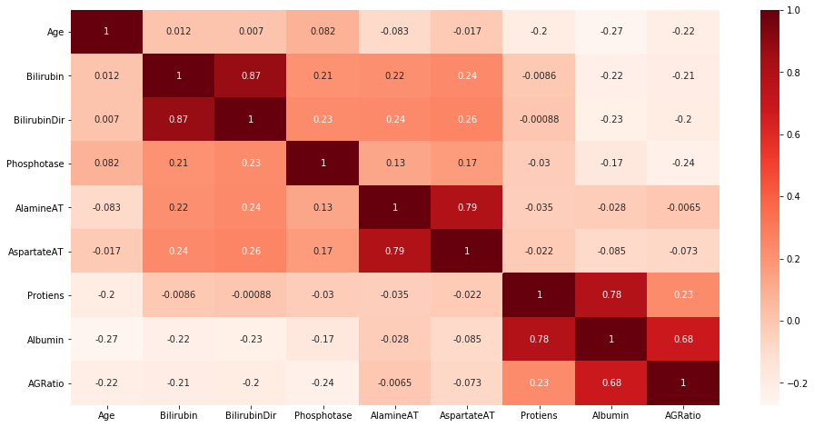

```python
# Check multivariate correlations
plt.figure(figsize=(16,8))
sb.heatmap(corr, cmap='Reds', annot=True)
plt.show()
```

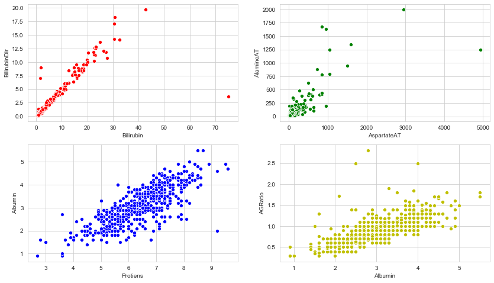

```python
# Plot correlations for >65% above using multi-variate plots
sb.set_style('whitegrid')
plt.figure(figsize=[14,8])
plt.subplot(2,2,1)
sb.scatterplot(x=aimd.Bilirubin, y=aimd.BilirubinDir, color='r')
plt.subplot(2,2,2)
sb.scatterplot(x=aimd.AspartateAT, y=aimd.AlamineAT, color='g')
plt.subplot(2,2,3)
sb.scatterplot(x=aimd.Protiens, y=aimd.Albumin, color='b')
plt.subplot(2,2,4)
sb.scatterplot(x=aimd.Albumin, y=aimd.AGRatio, color='y')
plt.show()
```

```python
import statsmodels.api as sm
from statsmodels.stats.outliers_influence import variance_inflation_factor
# Calculate VIF scores
X = aimd.drop(['Disease'], axis=1)
vif = pd.DataFrame([variance_inflation_factor(X.values, i) for i in range(X.shape[1])], columns=['VIF Score'], index=X.columns)
round(vif, 2).sort_values(by='VIF Score').T
# VIF scores are higher since scaling has not been performed, will check VIF again after scaling and dropping features
```

|  | Phosphotase | AspartateAT | AlamineAT | Bilirubin | BilirubinDir | Age | AGRatio | Protiens | Albumin |
| --- | --- | --- | --- | --- | --- | --- | --- | --- | --- |
| VIF Score | 2.63 | 3.18 | 3.29 | 5.45 | 5.72 | 7.59 | 24.4 | 96.88 | 128.94 |

```python
# Recursive Feature Elimination
#from sklearn.feature_selection import RFE
#from sklearn.linear_model import LogisticRegression

#y=['Disease']
#X=[i for i in aimd.columns if i!='Disease']
##X=['Age', 'Bilirubin', 'Phosphotase', 'AlamineAT', 'Protiens', 'AGRatio']
#print(X)
#rfe = RFE(LogisticRegression(), 6).fit(aimd[X], aimd[y])
#print(rfe.support_)
#print(rfe.ranking_)
```

```python
# Keep a copy for sklearn
aimd_orig = aimd.copy()
# Normalize features to have the models (GradientDescent and GaussianNB) work properly
X = ['Age', 'Phosphotase', 'Bilirubin', 'AlamineAT', 'Protiens', 'AGRatio', 'BilirubinDir', 'Albumin', 'AspartateAT']
aimd[X] = (aimd[X] - aimd[X].mean())/aimd[X].std()
display(aimd.head(3), aimd.tail(2))
```

|  | Age | Bilirubin | BilirubinDir | Phosphotase | AlamineAT | AspartateAT | Protiens | Albumin | AGRatio | Disease |
| --- | --- | --- | --- | --- | --- | --- | --- | --- | --- | --- |
| 0 | 1.240651 | -0.418280 | -0.493269 | -0.427046 | -0.351174 | -0.314152 | 0.279044 | 0.189571 | -0.150757 | 1 |
| 1 | 1.055947 | 1.209049 | 1.412682 | 1.660264 | -0.086670 | -0.032249 | 0.922249 | 0.064071 | -0.653096 | 1 |
| 2 | 1.055947 | 0.634697 | 0.918547 | 0.808217 | -0.108712 | -0.142260 | 0.462817 | 0.189571 | -0.182153 | 1 |

|  | Age | Bilirubin | BilirubinDir | Phosphotase | AlamineAT | AspartateAT | Protiens | Albumin | AGRatio | Disease |
| --- | --- | --- | --- | --- | --- | --- | --- | --- | --- | --- |
| 568 | -0.852664 | -0.322555 | -0.352087 | -0.439276 | -0.279537 | -0.266022 | 0.279044 | 0.315071 | 0.163205 | 1 |
| 569 | -0.421687 | -0.370417 | -0.422678 | -0.308819 | -0.323621 | -0.293525 | 0.738476 | 1.570070 | 1.733015 | 0 |

```python
# Build a model and check if VIF matters for the dataset
import statsmodels.api as sm
sm.Logit(aimd['Disease'].values, aimd.drop(['Disease'], axis=1).values).fit(disp=False).summary()
# Many p-values are >0.05 and are statistically insignificant, drop the correlated features and test again
```

Logit Regression Results

| Dep. Variable: | y | No. Observations: | 570 |
| --- | --- | --- | --- |
| Model: | Logit | Df Residuals: | 561 |
| Method: | MLE | Df Model: | 8 |
| Date: | Mon, 13 Jul 2020 | Pseudo R-squ.: | -0.06444 |
| Time: | 18:42:58 | Log-Likelihood: | -364.10 |
| converged: | True | LL-Null: | -342.06 |
| Covariance Type: | nonrobust | LLR p-value: | 1.000 |

|  | coef | std err | z | P>\|z\| | [0.025 | 0.975] |
| --- | --- | --- | --- | --- | --- | --- |
| x1 | 0.2233 | 0.093 | 2.413 | 0.016 | 0.042 | 0.405 |
| x2 | 0.0065 | 0.184 | 0.035 | 0.972 | -0.355 | 0.368 |
| x3 | 0.3317 | 0.201 | 1.654 | 0.098 | -0.061 | 0.725 |
| x4 | 0.2227 | 0.109 | 2.047 | 0.041 | 0.009 | 0.436 |
| x5 | 0.3176 | 0.248 | 1.282 | 0.200 | -0.168 | 0.803 |
| x6 | 0.0294 | 0.299 | 0.098 | 0.922 | -0.556 | 0.615 |
| x7 | 0.3838 | 0.240 | 1.596 | 0.110 | -0.087 | 0.855 |
| x8 | -0.5197 | 0.331 | -1.569 | 0.117 | -1.169 | 0.130 |
| x9 | 0.0973 | 0.201 | 0.484 | 0.629 | -0.297 | 0.492 |

```python
# Dropping all correlated variables:
#1. BilirubinDir is heavily correlated with BilirubinTot
#2. Albumin is correlated highly with both Protiens and AGRatio
#3. AspartateAT is strongly correlated with AlamineAT
aimd.drop(['BilirubinDir', 'Albumin', 'AspartateAT'], inplace=True, axis=1)
```

```python
# VIF after scaling and feature reduction
X = aimd.drop(['Disease'], axis=1)
vif = pd.DataFrame([variance_inflation_factor(X.values, i) for i in range(X.shape[1])], columns=['VIF Score'], index=X.columns)
round(vif, 2).sort_values(by='VIF Score').T
# All values are in a good range without significant collinearity
```

|  | AlamineAT | Age | Protiens | Phosphotase | Bilirubin | AGRatio |
| --- | --- | --- | --- | --- | --- | --- |
| VIF Score | 1.07 | 1.09 | 1.09 | 1.1 | 1.12 | 1.19 |

```python
# Build another model and check the summary
sm.GLM(aimd['Disease'].values, aimd.drop(['Disease'], axis=1).values,
       family=sm.families.Binomial()).fit().summary()
# Now most of them are significant except Protiens and AGRatio, keep them as they don't matter much and features are less anyway
```

Generalized Linear Model Regression Results

| Dep. Variable: | y | No. Observations: | 570 |
| --- | --- | --- | --- |
| Model: | GLM | Df Residuals: | 564 |
| Model Family: | Binomial | Df Model: | 5 |
| Link Function: | logit | Scale: | 1.0000 |
| Method: | IRLS | Log-Likelihood: | -366.98 |
| Date: | Mon, 13 Jul 2020 | Deviance: | 733.97 |
| Time: | 18:42:58 | Pearson chi2: | 556. |
| No. Iterations: | 5 |  |  |
| Covariance Type: | nonrobust |  |  |

|  | coef | std err | z | P>\|z\| | [0.025 | 0.975] |
| --- | --- | --- | --- | --- | --- | --- |
| x1 | 0.2360 | 0.092 | 2.567 | 0.010 | 0.056 | 0.416 |
| x2 | 0.3976 | 0.129 | 3.084 | 0.002 | 0.145 | 0.650 |
| x3 | 0.2343 | 0.109 | 2.154 | 0.031 | 0.021 | 0.448 |
| x4 | 0.3287 | 0.146 | 2.244 | 0.025 | 0.042 | 0.616 |
| x5 | 0.0350 | 0.092 | 0.380 | 0.704 | -0.145 | 0.216 |
| x6 | -0.1654 | 0.096 | -1.716 | 0.086 | -0.354 | 0.024 |

## Modelling using SKLearn

```python
# Import relevant sklearn libs
from sklearn.model_selection import train_test_split, GridSearchCV, StratifiedKFold, cross_val_score
from sklearn.preprocessing import StandardScaler
from sklearn.linear_model import LogisticRegression
from sklearn.naive_bayes import GaussianNB
from sklearn.neighbors import KNeighborsClassifier
from sklearn.metrics import confusion_matrix, classification_report, accuracy_score, f1_score, roc_curve, roc_auc_score, auc
```

```python
random_state=0
# Cross-Validation params
cv = StratifiedKFold(n_splits=10, shuffle=True, random_state=random_state)
target = 'Disease'
# Not considering the insignificant and correlated ones
features = ['Age','Phosphotase','Bilirubin','AlamineAT','Protiens','AGRatio']
```

### Naíve-Bayes Classification

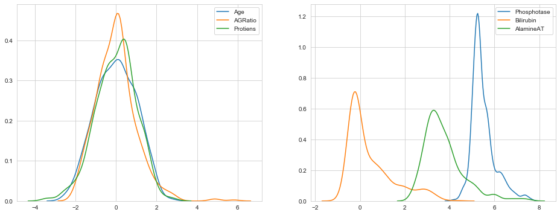

```python
# Some of the usuable un-correlated features are not Gaussian and slightly skewed, tweak those features to look Gaussian
# Check the feature densities after tweaking, they look more or less Gaussian now
plt.figure(figsize=[16,6])
plt.subplot(121)
sb.kdeplot(aimd.Age)
sb.kdeplot(aimd.AGRatio)
sb.kdeplot(aimd.Protiens)
plt.subplot(122)
sb.kdeplot(np.log(aimd_orig.Phosphotase))
sb.kdeplot(np.log(aimd_orig.Bilirubin))
sb.kdeplot(np.log(aimd_orig.AlamineAT))
plt.show()
```

```python
# Prepare parameters for modelling
aimd_nb = aimd.copy()
aimd_nb.AlamineAT = np.log(aimd_orig.AlamineAT + 1/3)
aimd_nb.Bilirubin = np.log(aimd_orig.Bilirubin + 0.1)
aimd_nb.Phosphotase = np.log(aimd_orig.Phosphotase + .125)
#aimd_nb = aimd_nb.fillna(0)
X = aimd_nb.loc[:, features]
y = aimd_nb[target]
X_train, X_test, y_train, y_test1 = train_test_split(X, y, train_size=2/3, test_size=1/3, stratify=y, random_state=random_state)

# Create the GaussianNB model
model_nb = GaussianNB()
model_nb.fit(X_train, y_train, sample_weight=None)
y_pred_nb = model_nb.predict(X_test)
y_pred_nb_prob = model_nb.predict_proba(X_test)[:,1]
print('Prediction Accuracy:', round(accuracy_score(y_test1, y_pred_nb), 3))

# CrossValidation
print("Average Cross-Validation Score: %.3f" % cross_val_score(model_nb, X, y, cv=cv).mean())
```

```
Prediction Accuracy: 0.626
Average Cross-Validation Score: 0.649
```

### Logistic Regression #1

```python
# Gather data and take all the features for modelling
X = aimd_orig.drop(['Disease'], axis=1)
y = aimd_orig['Disease']

# Normalize the data
X = StandardScaler(copy=False).fit(X).transform(X)

# Split to train and test
X_train, X_test, y_train, y_test2 = train_test_split(X, y, train_size=2/3, test_size=1/3, stratify=y, random_state=random_state)

# CrossValidation and GridSearch
best_model = GridSearchCV(LogisticRegression(), param_grid={'C':[x for x in range(1,7)], 'solver':['lbfgs','newton-cg']}, cv=cv)
best_model.fit(X,y)
print("Best Score: {:.3f}\nBest Params: {}".format(best_model.best_score_, best_model.best_params_))
```

```
Best Score: 0.730
Best Params: {'C': 6, 'solver': 'lbfgs'}
```

```python
# Fit LogisticRegression as per above params and  perform cross-validation
model_logit1 = LogisticRegression(penalty='l2', tol=0.00001, C=6., solver='lbfgs', max_iter=1000)
model_logit1.fit(X_train, y_train)
y_pred_logit1 = model_logit1.predict(X_test)
y_pred_logit1_prob = model_logit1.predict_proba(X_test)[:,1]
print('Prediction Accuracy:', round(accuracy_score(y_test2, y_pred_logit1), 3))
```

```
Prediction Accuracy: 0.705
```

### K-Nearest Neighbours

```python
# Check best K using sklearn
best_model = GridSearchCV(KNeighborsClassifier(), param_grid = {'n_neighbors':range(1,24), 'p':[1,2]}, cv = cv)
best_model.fit(X,y)
print("Best Score: {:.3f}\nBest Params: {}".format(best_model.best_score_, best_model.best_params_))

# K=23 presents a good accuracy trade-off and can be used to model with KNN
model_knn = KNeighborsClassifier(n_neighbors=23, p=1, weights='distance')
model_knn.fit(X_train, y_train)
y_pred_knn = model_knn.predict(X_test)
y_pred_knn_prob = model_knn.predict_proba(X_test)[:,1]
print('Prediction Accuracy:', round(accuracy_score(y_test2, y_pred_knn), 3))
```

```
Best Score: 0.700
Best Params: {'n_neighbors': 23, 'p': 1}
Prediction Accuracy: 0.705
```

### Logistic Regression #2

```
Optimization terminated successfully.
         Current function value: 0.632533
         Iterations: 6
         Function evaluations: 8
         Gradient evaluations: 47
         Hessian evaluations: 0
Age            0.296776
Phosphotase    0.353314
Bilirubin      0.393465
AlamineAT      0.342239
Protiens       0.063241
AGRatio       -0.201064
dtype: float64
```

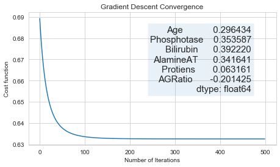

```python
# Get the data
X = aimd.loc[:, features]
y = aimd[target]
X_train, X_test, y_train, y_test3 = train_test_split(X, y, train_size=2/3, test_size=1/3, random_state=random_state)

# Sigmoid function
def sigmoid(Z):
    return 1/(1 + np.exp(-Z))

# Cost function
def costFunc(theta, X, y):
    return ((-1/y.size)* (y.T.dot(np.log(sigmoid(X.dot(theta)))) + (1-y).T.dot(np.log(1-sigmoid(X.dot(theta))))))

# Gradient function
def gradient(theta, X, y):
    return ((X.T).dot(sigmoid(X.dot(theta)) - y))/y.size

# Gradient Descent for Optimization
def gradientDescent(theta, X, y, alpha=0.1, iters=500):
    samples = y.size
    costHist = []
    for i in range(iters):
        delta = gradient(theta, X, y)
        theta -= alpha * delta
        costHist.append(costFunc(theta,X,y))
    return theta, costHist

# Use advanced optimization techniques to validate the theta values
from scipy.optimize import minimize
theta_adv = minimize(fun=costFunc, x0=np.ones(X.shape[1]), args=(X_train, y_train.values),
                     method='Newton-CG', jac=gradient, options={'maxiter':500, 'disp':True}).x

# Use the code to get the parameters at gradient convergence
theta, costHist = gradientDescent(np.zeros(X.shape[1]), X_train, y_train.values)
# Check that the thetas almost match
print(theta_adv)

# Plot Gradient Descent Convergence
plt.figure(figsize=(16,4))
sb.set_style("whitegrid")
ax = plt.subplot(1,2,1)
plt.plot(np.arange(len(costHist)),costHist)
plt.title('Gradient Descent Convergence')
plt.xlabel('Number of Iterations')
plt.ylabel('Cost function')
plt.text(0.9, 0.9, '{}'.format(theta),
         fontsize=15, horizontalalignment='right', verticalalignment='top', bbox=dict(alpha=0.1), transform=ax.transAxes)
plt.show()

# Predictions and results (setting threshold at 30% prob for better results)
y_pred_logit2_prob = sigmoid(X_test.dot(theta_adv))
y_pred_logit2 = pd.Series(y_pred_logit2_prob).map(lambda x: 0 if x<.3 else 1)
```

## Evaluate and Compare Model Performance

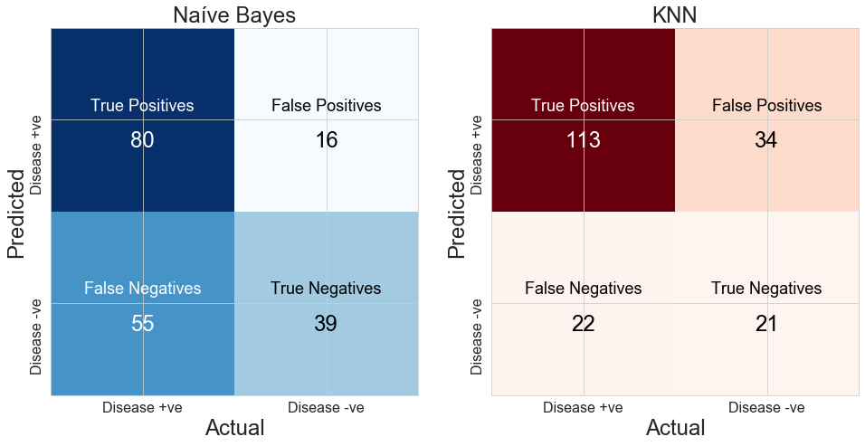

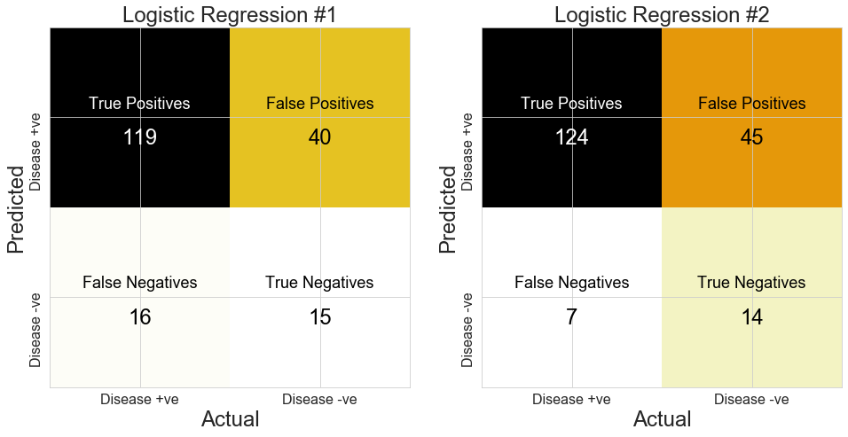

```python
# Function to print confusion matrix with TP, FP, TN, FN
from itertools import product
def cm_axes(y_test, y_pred, title, cmap):
    conf_mat = np.rot90(confusion_matrix(y_test, y_pred), 2).T
    classes=['Disease +ve','Disease -ve']
    plt.xlabel('Actual', size = 24)
    plt.ylabel('Predicted', size = 24)
    plt.title(title, size = 24)
    plt.imshow(conf_mat, interpolation='nearest', cmap=cmap)
    tick_marks = np.arange(len(classes))
    plt.xticks(tick_marks, classes, rotation = 0, size = 16)
    plt.yticks(tick_marks, classes, rotation = 90, size = 16)
    rows = [['True Positives', 'False Positives'],
            ['False Negatives', 'True Negatives']]
    for i, j in product(range(conf_mat.shape[0]), range(conf_mat.shape[1])):
        plt.text(j, i - 0.05, format(rows[i][j]),
        horizontalalignment="center", size = 18,
        color="white" if conf_mat[i, j] > conf_mat.max() / 2. else "black")
        plt.text(j, i + 0.15, format(conf_mat[i, j], ''),
        horizontalalignment="center", size = 24,
        color="white" if conf_mat[i, j] > conf_mat.max() / 2. else "black")
    return plt

# Draw and check the heat-map for all models to find TP, TN, FP and FN
#sb.heatmap(confusion_matrix(y_test, y_pred), annot=True, fmt='d', xticklabels=classes, yticklabels=classes)
plt.figure(figsize=(16,8))
plt.subplot(121)
cm_axes(y_test1, y_pred_nb, 'Naíve Bayes', plt.cm.Blues)
plt.subplot(122)
cm_axes(y_test2, y_pred_knn, 'KNN', plt.cm.Reds)
plt.show()
plt.figure(figsize=(16,8))
plt.subplot(121)
cm_axes(y_test2, y_pred_logit1, 'Logistic Regression #1', plt.cm.CMRmap_r)
plt.subplot(122)
cm_axes(y_test3, y_pred_logit2, 'Logistic Regression #2', plt.cm.CMRmap_r)
plt.show()
```

```python
# Print full classification report showing precision, recall, etc.
class formatter:
   PURPLE = '\033[95m'
   CYAN = '\033[96m'
   DARKCYAN = '\033[36m'
   BLUE = '\033[94m'
   GREEN = '\033[92m'
   YELLOW = '\033[93m'
   RED = '\033[91m'
   BOLD = '\033[1m'
   UNDERLINE = '\033[4m'
   END = '\033[0m'

print(formatter.BOLD + formatter.UNDERLINE + 'Report for Naíve Bayes\n' + formatter.END)
print(classification_report(y_test1, y_pred_nb, digits=3, target_names=['Disease -ve', 'Disease +ve']))
print('\n' + formatter.BOLD + formatter.UNDERLINE + 'Report for KNN\n' + formatter.END)
print(classification_report(y_test2, y_pred_knn, digits=3, target_names=['Disease -ve', 'Disease +ve']))
print('\n' + formatter.BOLD + formatter.UNDERLINE + 'Report for Logistic Regression #1\n' + formatter.END)
print(classification_report(y_test2, y_pred_logit1, digits=3, target_names=['Disease -ve', 'Disease +ve']))
print('\n' + formatter.BOLD + formatter.UNDERLINE + 'Report for Logistic Regression #2\n' + formatter.END)
print(classification_report(y_test3, y_pred_logit2, digits=3, target_names=['Disease -ve', 'Disease +ve']))
```

```
Report for Naíve Bayes

              precision    recall  f1-score   support

 Disease -ve      0.415     0.709     0.523        55
 Disease +ve      0.833     0.593     0.693       135

    accuracy                          0.626       190
   macro avg      0.624     0.651     0.608       190
weighted avg      0.712     0.626     0.644       190


Report for KNN

              precision    recall  f1-score   support

 Disease -ve      0.488     0.382     0.429        55
 Disease +ve      0.769     0.837     0.801       135

    accuracy                          0.705       190
   macro avg      0.629     0.609     0.615       190
weighted avg      0.688     0.705     0.693       190


Report for Logistic Regression #1

              precision    recall  f1-score   support

 Disease -ve      0.484     0.273     0.349        55
 Disease +ve      0.748     0.881     0.810       135

    accuracy                          0.705       190
   macro avg      0.616     0.577     0.579       190
weighted avg      0.672     0.705     0.676       190


Report for Logistic Regression #2

              precision    recall  f1-score   support

 Disease -ve      0.667     0.237     0.350        59
 Disease +ve      0.734     0.947     0.827       131

    accuracy                          0.726       190
   macro avg      0.700     0.592     0.588       190
weighted avg      0.713     0.726     0.679       190
```

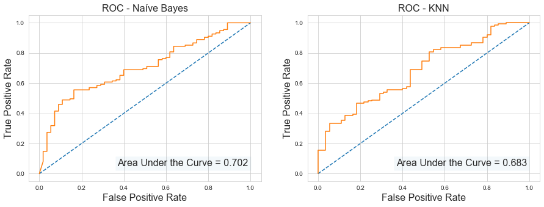

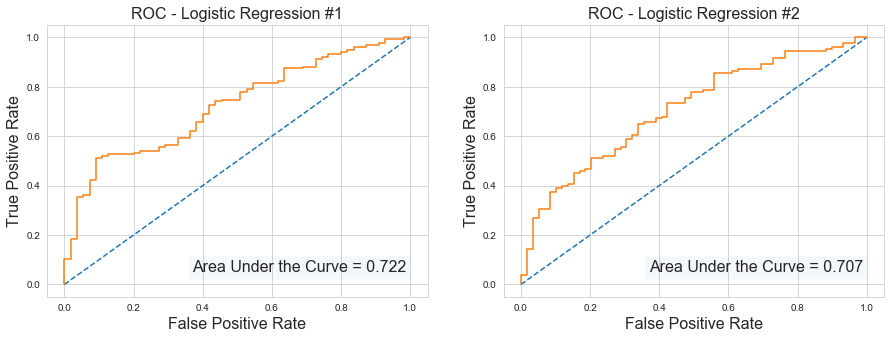

```python
# ROC Plots for all models
def rocUtils(y_test, y_pred_prob, title,):
    fpr, tpr, thresholds = roc_curve(y_test, y_pred_prob)
    plt.plot([0,1], [0,1], '--')
    plt.text(0.99, 0.1, 'Area Under the Curve = %.3f' % roc_auc_score(y_test, y_pred_prob),
            fontsize=16, horizontalalignment='right', verticalalignment='top', bbox=dict(alpha=0.05))
    plt.plot(fpr, tpr)
    plt.xlabel('False Positive Rate', size=16)
    plt.ylabel('True Positive Rate', size=16)
    plt.title('ROC - ' + title, size=16)

plt.figure(figsize=(15,5))
plt.subplot(121)
rocUtils(y_test1, y_pred_nb_prob, 'Naíve Bayes')
plt.subplot(122)
rocUtils(y_test2, y_pred_knn_prob, 'KNN')
plt.show()
plt.figure(figsize=(15,5))
plt.subplot(121)
rocUtils(y_test2, y_pred_logit1_prob, 'Logistic Regression #1')
plt.subplot(122)
rocUtils(y_test3, y_pred_logit2_prob, 'Logistic Regression #2')
plt.show()
```

```python
# ROC Cut-Off
fpr, tpr, thresholds = roc_curve(y_test3, y_pred_logit2_prob)
roc_auc = auc(fpr, tpr)
print("Area under the ROC curve : %f" % roc_auc)

i = np.arange(len(tpr))
roc = pd.DataFrame({'fpr':pd.Series(fpr, index=i), 'tpr':pd.Series(tpr, index = i), '1-fpr':pd.Series(1-fpr, index = i),
                    'tf':pd.Series(tpr - (1-fpr), index = i), 'thresholds':pd.Series(thresholds, index = i)})
roc.iloc[(roc.tf-0).abs().argsort()[:1]]
```

```
Area under the ROC curve : 0.707465
```

|  | fpr | tpr | 1-fpr | tf | thresholds |
| --- | --- | --- | --- | --- | --- |
| 37 | 0.355932 | 0.648855 | 0.644068 | 0.004787 | 0.398038 |

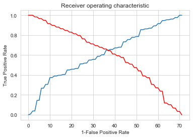

```python
# Plot tpr vs 1-fpr
fig, ax = plt.subplots()
plt.plot(roc['tpr'])
plt.plot(roc['1-fpr'], color = 'red')
plt.xlabel('1-False Positive Rate')
plt.ylabel('True Positive Rate')
plt.title('Receiver operating characteristic')
#ax.set_xticklabels([])
plt.show()
```

## Summary

Having built multiple classification models (best ones with feature engineering), the following is concluded -

1. Naíve Bayes: Generally the accuracy and recall is poor. Even with the best model, scores are poorer than K-NN or Logistic Regression although the precision is good. Without feature engineering (and considering all features), accuracy is lesser (~ 56%) and recall degrades even further (~ 0.42)
2. K-NN: Performs equally or better than Naíve Bayes and similar to Logistic Regression (although not always)
3. Logistic Regression: Performs equally or gets the better of the 3 algorithms (with/without feature engineering and optimizations). Two models were built, one with hand-written code and reduced features and the other with SKLearn with all the features and both perform very similar. Advantage of SKLearn is not having to choose a threshold for the Sigmoid which can be customized with own code

This shows that with the Naíve assumptions, Naíve Bayes perfoms poorly (non-correlation and feature independence). Logistic Regression accounts for correlations as well and performace does not degrade (shown in model #1 with all features).